# Scenario: Boat Harvest Implementation @ Ballard

Describing the model run when boat-based harvest is amplified above incidental levels at Ballard

October 23, 2024

### The Narrative

This Model Run is for a scenario where managers open harvest of seals in the gauntlet by fishing vessels during the Coho fishery. This is modeled similarly to incidental fishery take in the base run but at a higher exploitation rate.

### Run the Model

Parameters listed below are altered from the base run parameterization to simulate the management scenario.

```r
# adjust parameters for management scenario
steepness_H <- 5 # how quick does it saturate (higher = slower)
availability <- 0.1 # prop of seals spatially overlapping with fishers
accuracy <- 0.9 # prop harvested of encountered
efficiency <- availability * accuracy # what prop of seals are they actually
```

### Description of Parameterization

This scenario is focused on the effects of a management strategy that changes the quantity of seal harvest. Removals occur on days when the coho fishery is open in the gauntlet. The harvest strategy is still boat-based like incidental harvest but it is more aggressive as it is focused on seal removal directly not incidentally as in the base run.

Removals occur from day 253 - 321 of the year. When there are 150 harbor seals, 5 California sea lions, and 1 Steller sea lions in the source pool, pinniped presence at the Gauntlet is as follows:

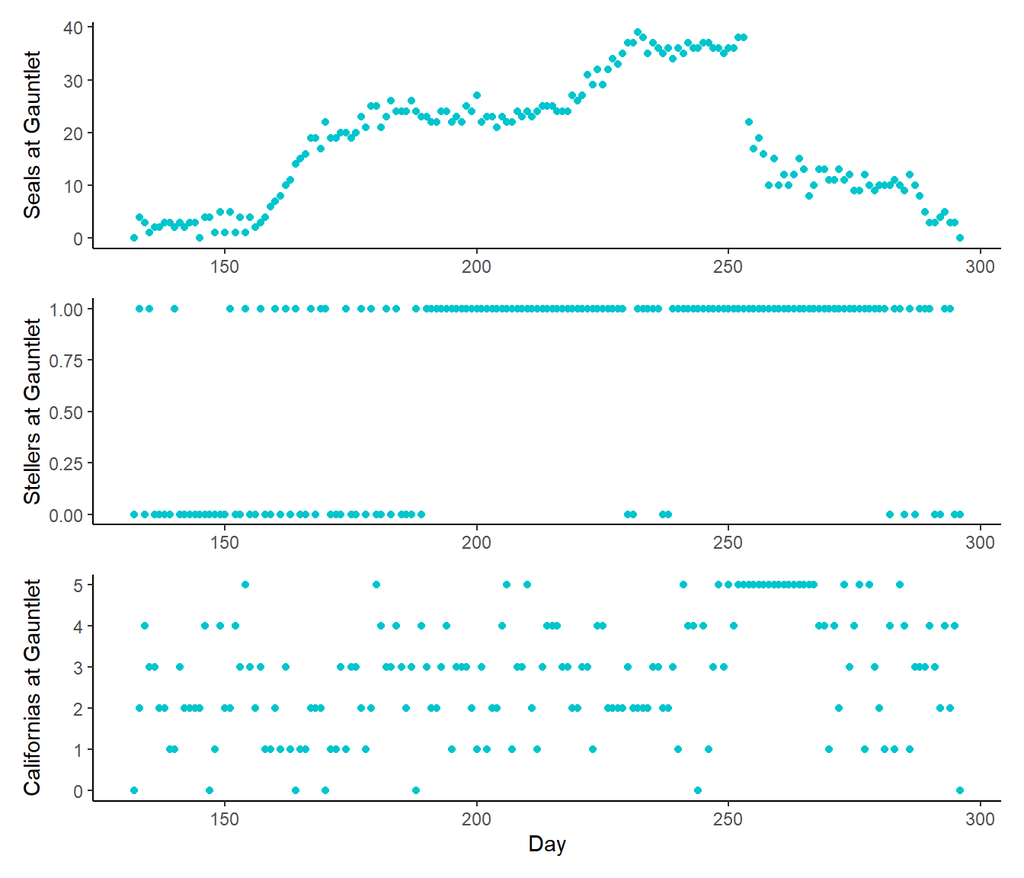

…and when there are 40 individual pinnipeds at the Gauntlet, removals are a type 2 function as follows:

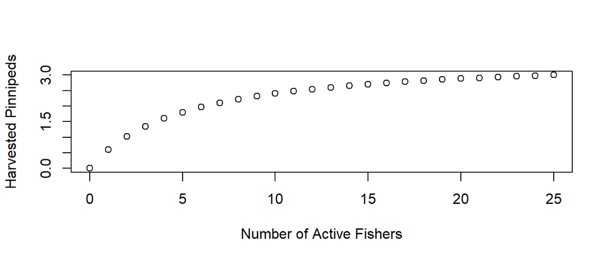

The harvest efficiency is set at 0.09, which represents both the proportion of pinnipeds in the gauntlet that are available to harvesters multiplied by the proportion of pinnipeds that harvesters are able to kill of the ones they encounter. In the Locks, fishers are only operating above the Locks in the ship canal, so the only pinnipeds that are available to them are the ones that go above the Locks in pursuit of fish (est. 10% of seals, no sea lions). I then assume that fishers kill 90% of the pinnipeds they encounter. This results in a 0.09 harvest efficiency for boat-based effort by Muckleshoot fishers.

I also increase the proportion of fishers who are engaging in harvest activity by increasing the rate at which the type II functional response that defines harvest per fisher reaches saturation. So in practice it takes fewer fishers to be on the water in a given day for the max seals to be harvested.

The total harvested pinnipeds are as follows under this parameterization:

| Pv | Ej | Zc |
| --- | --- | --- |
| 18 | 0 | 0 |

This level of harvest impacts the fear response of the pinnipeds that are exposed to harvest and causes fewer of them to go to the Gauntlet than in the base run.

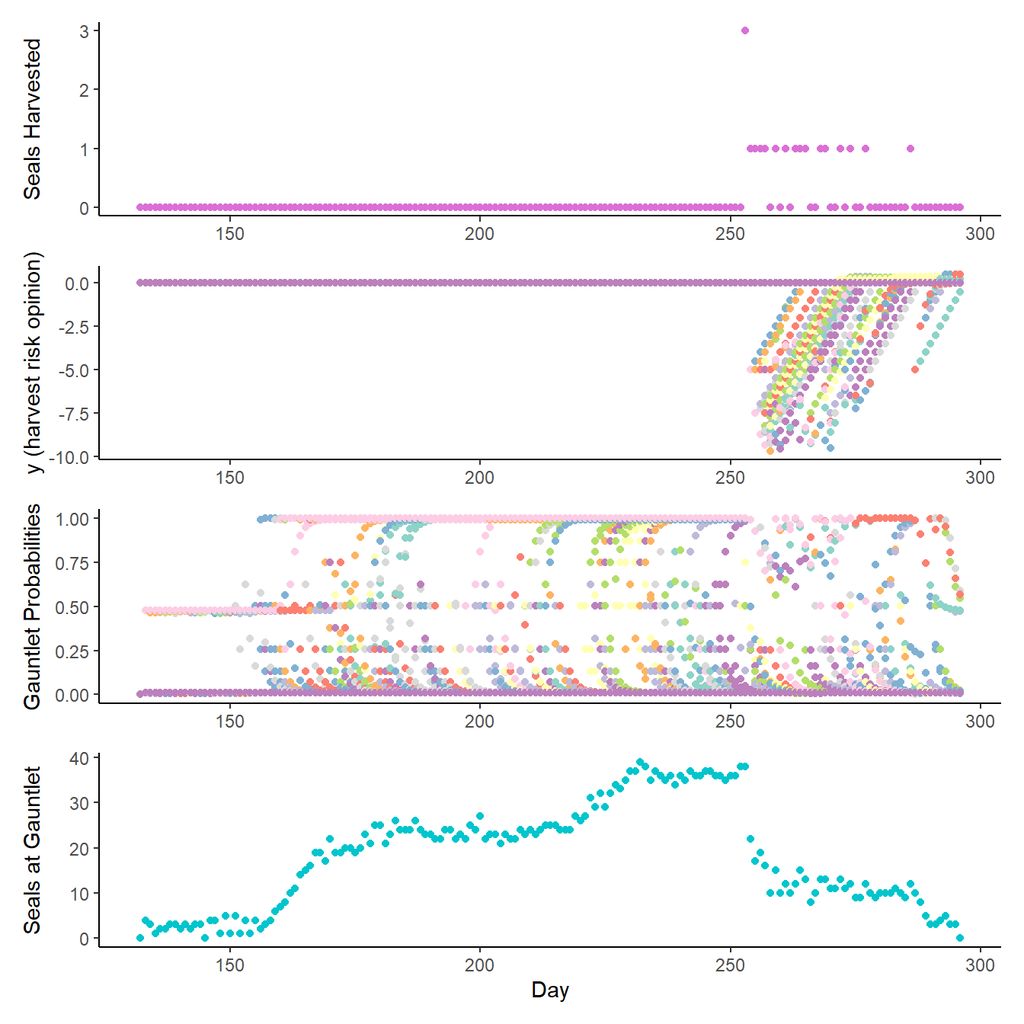

In this scenario, pinnipeds still have a noticeable predation impact on all three salmon runs. However, this impact is lessened on the Coho run, which is when the boat-based harvest is occurring, reinforcing the fear conditioning and causing a reduced seal predation impact.

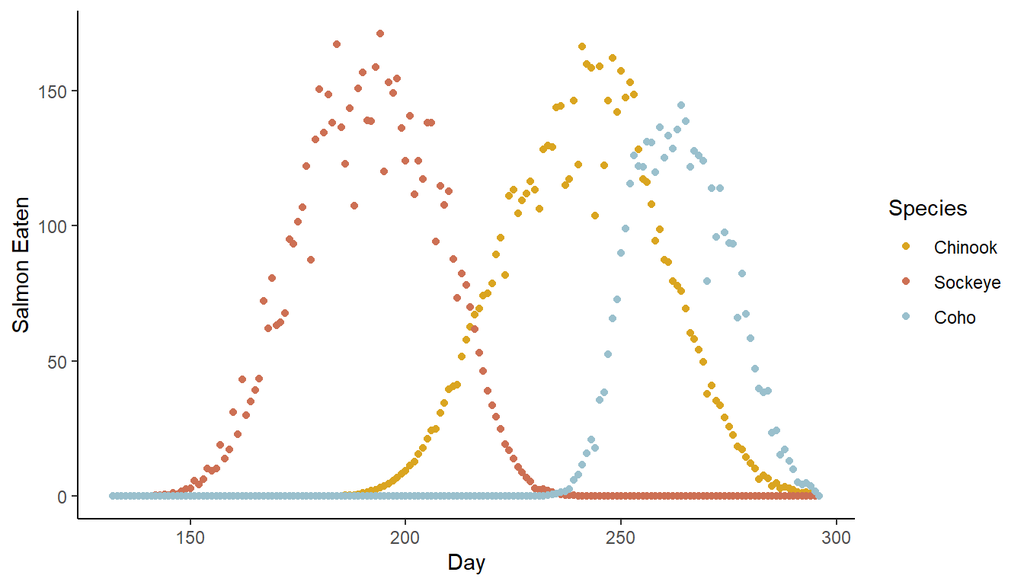

### Salmon Response

The fate of the sockeye, Chinook, and coho are as follows under this parameterization:

|  | Sockeye | Chinook | Coho |
| --- | --- | --- | --- |
| Escape | 62383 | 1778 | 8934 |
| Catch | 0 | 645 | 4102 |
| Predated | 6470 | 6858 | 4096 |

### Parameter Table

|  | Value |
| --- | --- |
| num_seals | 150 |
| num_seals_2_copy | 75 |
| sockeye_residence | 3 |
| chinook_residence | 66 |
| coho_residence | 10 |
| min_fishers | 13 |
| max_fishers | 25 |
| fishery_open | 253 |
| fishery_close | 321 |